# Staying indoors is the new normalcy

## More confirmed cases in the past 7 days correlate with lower mobility?

conrfirmed cases rates: 7-Day Cases Rate per 100000, the number of COVID-19 cases for every 100,000 people over the last 7 days (May 5 - May 11)

data source: [CDC](https://covid.cdc.gov/covid-data-tracker/#cases_casesper100klast7days)

```python
cases = pd.read_csv('united_states_covid19_cases_deaths_and_testing_by_state.csv', header=2)
cases.columns
```

```
Index(['State/Territory', 'Total Cases', 'Confirmed Cases', 'Probable Cases',
       'Cases in Last 7 Days', 'Case Rate per 100000', 'Total Deaths',
       'Confirmed Deaths', 'Probable Deaths', 'Deaths in Last 7 Days',
       'Death Rate per 100000', '7-Day Cases Rate per 100000',
       '7-Day Death Rate per 100000', 'Total % Positive',
       '% Positive Last 30 Days', '% Positive Last 7 Days', '# Tests per 100K',
       'Total # Tests', '# Tests per 100K Last 7 Days',
       'Total # Tests Last 7 Days', '# Tests per 100K Last 30 Days',
       'Total # Tests Last 30 Days', 'New Cases', 'New Deaths'],
      dtype='object')
```

```python
cases = cases[['State/Territory', '7-Day Cases Rate per 100000']]
```

```
cases vs retail_recreation_change_diff
pearson correlation: 0.065
p-value: 0.652
cases vs groce_pharm_change_diff
pearson correlation: 0.039
p-value: 0.787
cases vs parks_change_diff
pearson correlation: 0.158
p-value: 0.268
cases vs transit_change_diff
pearson correlation: -0.168
p-value: 0.238
cases vs workplaces_change_diff
pearson correlation: 0.047
p-value: 0.743
cases vs residential_change_diff
pearson correlation: 0.066
p-value: 0.647
```

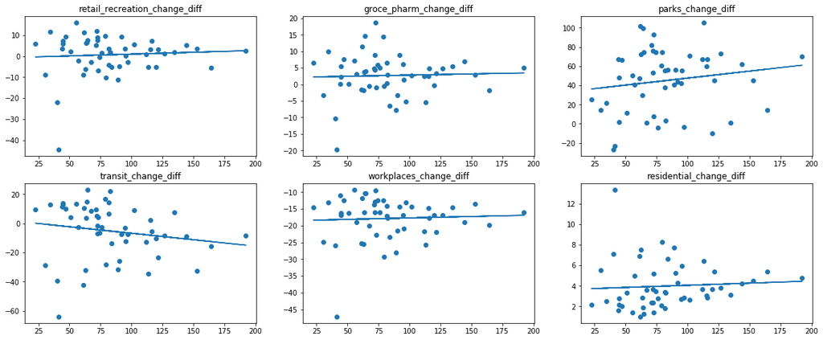

```python
fig, ax = plt.subplots(nrows=2, ncols=3, figsize=(20, 8))
l = ["retail_recreation_change_diff","groce_pharm_change_diff","parks_change_diff","transit_change_diff","workplaces_change_diff","residential_change_diff"]

for i in range(len(l)):
    mobility = l[i]
    d = recGap[['state', mobility]]
    data = d.merge(cases, left_on='state', right_on='State/Territory')
    x = data['7-Day Cases Rate per 100000']
    y = data[mobility]
    m, b = np.polyfit(x, y, 1)
    ax[math.floor(i/3),i%3].scatter(x, y)
    ax[math.floor(i/3),i%3].plot(x, m*x + b)
    ax[math.floor(i/3),i%3].set_title(l[i])
    # calculate Pearson's correlation
    corr, p = pearsonr(x, y)
    print('cases vs ' + l[i] )
    print('pearson correlation: %.3f' % corr)
    print('p-value: %.3f' % p)
```

all p-values are larger than our assumed alpha level of 0.05, meaning that there are no significant correlations.

## Higher vaccinations rates correlate with higher mobility?

Vaccination rates: Percentage of adults who have received a COVID-19 vaccine between March 17, 2021 and March 29, 2021.

data: Household Pulse Survey https://www.census.gov/data-tools/demo/hhp/#/?measures=VACCINE&periodSelector=27

```python
vac = pd.read_excel("vac-percent.xlsx", header=1).drop(0)[["Area", "Percent"]].iloc[:51, :]
vac = vac.rename(columns={'Percent': 'percent_vac'})
```

```
vac vs retail_recreation_change_diff
pearson correlation: -0.103
p-value: 0.474
vac vs groce_pharm_change_diff
pearson correlation: 0.001
p-value: 0.993
vac vs parks_change_diff
pearson correlation: -0.220
p-value: 0.121
vac vs transit_change_diff
pearson correlation: 0.046
p-value: 0.751
vac vs workplaces_change_diff
pearson correlation: 0.037
p-value: 0.796
vac vs residential_change_diff
pearson correlation: 0.029
p-value: 0.838
```

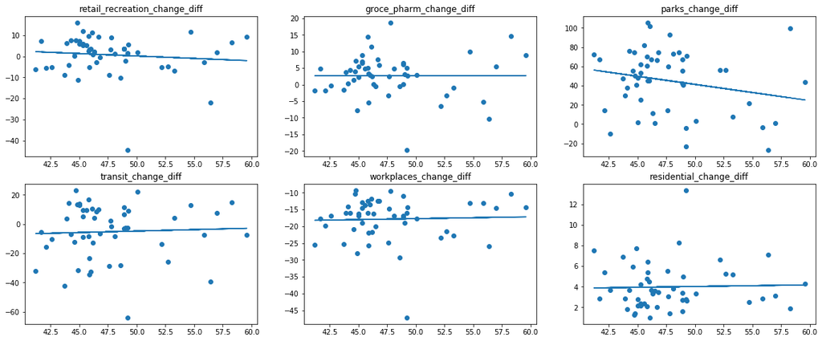

```python
fig, ax = plt.subplots(nrows=2, ncols=3, figsize=(20, 8))
l = ["retail_recreation_change_diff","groce_pharm_change_diff","parks_change_diff","transit_change_diff","workplaces_change_diff","residential_change_diff"]

for i in range(len(l)):
    mobility = l[i]
    d = recGap[['state', mobility]]
    data = d.merge(vac, left_on='state', right_on='Area')
    x = data.percent_vac
    y = data[mobility]
    m, b = np.polyfit(x, y, 1)
    ax[math.floor(i/3),i%3].scatter(x, y)
    ax[math.floor(i/3),i%3].plot(x, m*x + b)
    ax[math.floor(i/3),i%3].set_title(l[i])
    # calculate Pearson's correlation
    corr, p = pearsonr(x, y)
    print('vac vs ' + l[i] )
    print('pearson correlation: %.3f' % corr)
    print('p-value: %.3f' % p)
```

all p-values are larger than our assumed alpha level of 0.05, meaning that there are no significant correlations in the variables.